# Internal Ethylene Concentrations Data Analysis

Jimmy Larson

10/27/2020

## Introduction

This file analyzes the data for internal ethylene concentrations (IEC) for the preharvest drop study conducted from Aug.-Oct. 2020. 10 fruit from each of the five reps and four treatments: AVG, NAA, Ethephon, and an untreated control had their internal ethylene measured using gas chromatography. A 1ml gas sample was obtained by inserting a hypodermic needle into the calyx end of the apple. IEC was measured on the following dates:

- August 28
- September 1
- September 7
- September 14
- September 21
- September 29
- October 12

## Join Data

Each subsequent date was joined to the first measurement date…

```r
iecAug28 %>%
  rename(iec.Aug.28 = IEC) %>%
  left_join(iecSep1) %>%
  rename(iec.Sep.1 = IEC) %>%
  left_join(iecSep7) %>%
  rename(iec.Sep.7 = IEC) %>%
  left_join(iecSep14) %>%
  rename(iec.Sep.14 = IEC) %>%
  left_join(iecSep21) %>%
  rename(iec.Sep.21 = IEC) %>%
  left_join(iecSep29) %>%
  rename(iec.Sep.29 = IEC) %>%
  left_join(iecOct12) %>%
  rename(iec.Oct.12 = IEC) %>%
  select(row, treatment, rep, fruit, iec.Aug.28, iec.Sep.1, iec.Sep.7, iec.Sep.14,
         iec.Sep.21, iec.Sep.29, iec.Oct.12) -> iec
```

Long form data frame was created…

```r
iec %>%
  gather('iec.Aug.28', 'iec.Sep.1', 'iec.Sep.7', 'iec.Sep.14', 'iec.Sep.21', 'iec.Sep.29', 'iec.Oct.12',
         key = "measDate", value = "iec") %>%
  mutate(date = case_when(measDate == 'iec.Aug.28' ~ mdy("8/28/2020"),
                          measDate == 'iec.Sep.1' ~ mdy("9/1/2020"),
                          measDate == 'iec.Sep.7' ~ mdy("9/7/2020"),
                          measDate == 'iec.Sep.14' ~ mdy("9/14/2020"),
                          measDate == 'iec.Sep.21' ~ mdy("9/21/2020"),
                          measDate == 'iec.Sep.29' ~ mdy("9/29/2020"),
                          measDate == 'iec.Oct.12' ~ mdy("10/12/2020"))) -> iecLong
```

## Explore Data

A box plot of the data was first made…

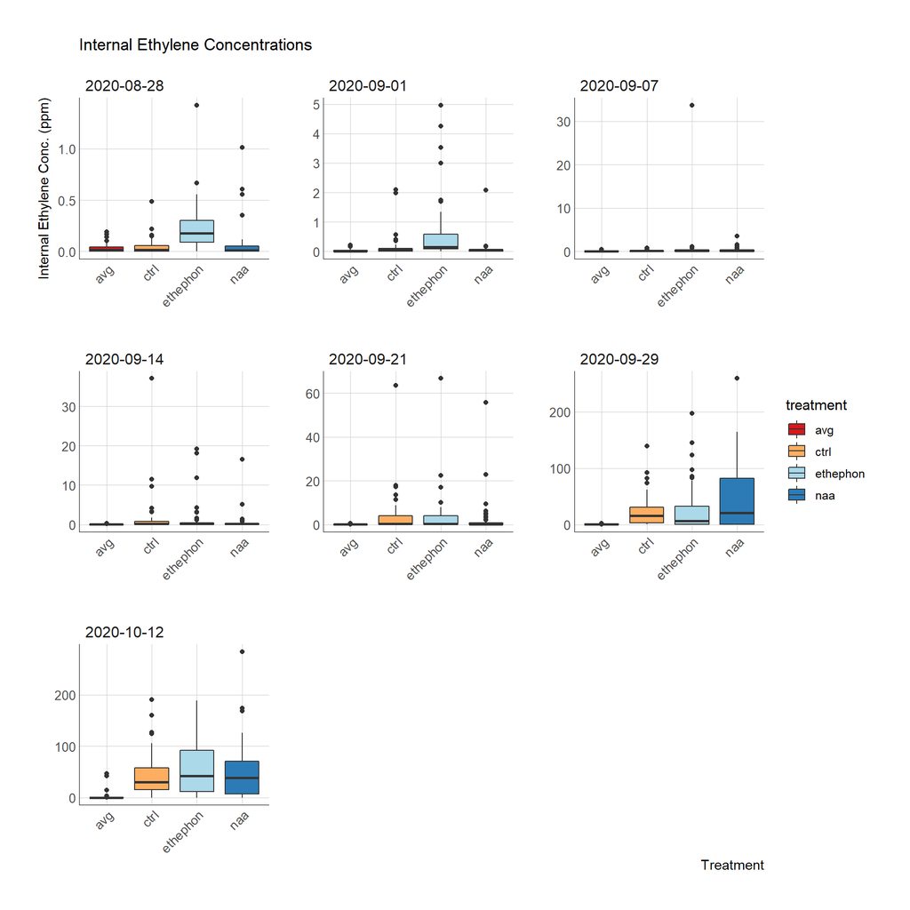

We then explored the spread of the data on a natural log scale…

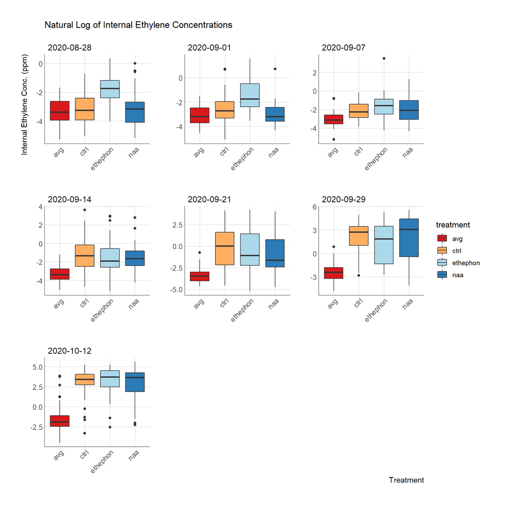

The below density plots show that taking the natural log of the data provides a more normal distribution…

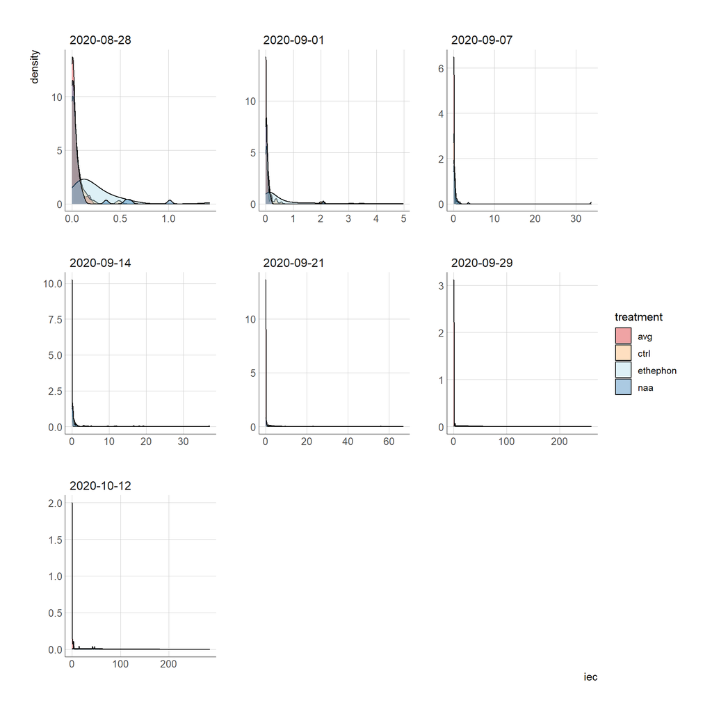

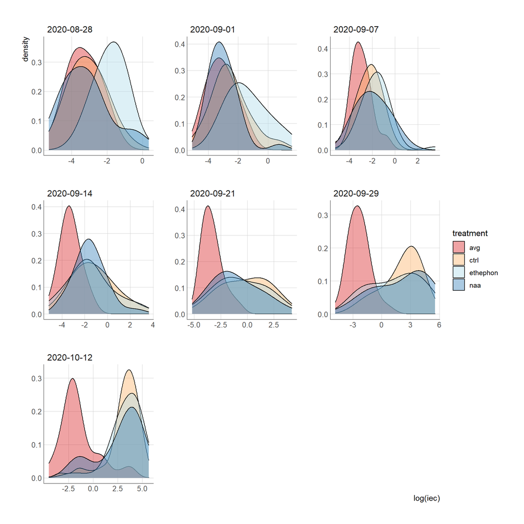

## ANOVA Assumptions

### Untransformed Data

To check ANOVA assumptions an ANOVA model was built on each date…

```r
iecAug28.aov <- aov(iec.Aug.28 ~ treatment, data = iec)
```

Shapiro Wilkes test was done on the residuals to determine whether the data was normally distributed…

```r
iecAug28.resid <- residuals(object = iecAug28.aov)
shapiro.test(x = iecAug28.resid)
```

Then Levene’s test was done to check for homogeneity of variance…

```r
leveneTest(iec.Aug.28 ~ treatment, data = iec)
```

The following are the p-values for these test statics on each date…

#### **Aug. 28**

Test statistic was significant for both Shapiro-Wilkes and Levene’s test…

```
##
##  Shapiro-Wilk normality test
##
## data:  iecAug28.resid
## W = 0.6212, p-value < 2.2e-16
```

```
## Levene's Test for Homogeneity of Variance (center = median)
##        Df F value    Pr(>F)
## group   3  7.5756 8.108e-05 ***
##       194
## ---
## Signif. codes:  0 '***' 0.001 '**' 0.01 '*' 0.05 '.' 0.1 ' ' 1
```

#### **Sep. 1**

Test statistic was significant for both Shapiro-Wilkes and Levene’s test…

```
##
##  Shapiro-Wilk normality test
##
## data:  iecSep1.resid
## W = 0.49923, p-value < 2.2e-16
```

```
## Levene's Test for Homogeneity of Variance (center = median)
##        Df F value    Pr(>F)
## group   3  8.1451 3.924e-05 ***
##       192
## ---
## Signif. codes:  0 '***' 0.001 '**' 0.01 '*' 0.05 '.' 0.1 ' ' 1
```

#### **Sep. 7**

p<0.05 was significant for Shapiro-Wilkes but variance was homogenous…

```
##
##  Shapiro-Wilk normality test
##
## data:  iecSep7.resid
## W = 0.13474, p-value < 2.2e-16
```

```
## Levene's Test for Homogeneity of Variance (center = median)
##        Df F value Pr(>F)
## group   3   1.186 0.3163
##       193
```

#### **Sep. 14**

p<0.05 was significant for Shapiro-Wilkes but variance was homogenous…

```
##
##  Shapiro-Wilk normality test
##
## data:  iecSep14.resid
## W = 0.34479, p-value < 2.2e-16
```

```
## Levene's Test for Homogeneity of Variance (center = median)
##        Df F value Pr(>F)
## group   3  1.9903 0.1168
##       191
```

#### **Sep. 21**

p<0.05 was significant for Shapiro-Wilkes but variance was homogenous…

```
##
##  Shapiro-Wilk normality test
##
## data:  iecSep21.resid
## W = 0.38521, p-value < 2.2e-16
```

```
## Levene's Test for Homogeneity of Variance (center = median)
##        Df F value  Pr(>F)
## group   3  2.3358 0.07514 .
##       192
## ---
## Signif. codes:  0 '***' 0.001 '**' 0.01 '*' 0.05 '.' 0.1 ' ' 1
```

#### **Sep. 29**

Test statistic was significant for both Shapiro-Wilkes and Levene’s test…

```
##
##  Shapiro-Wilk normality test
##
## data:  iecSep29.resid
## W = 0.78553, p-value = 1.692e-15
```

```
## Levene's Test for Homogeneity of Variance (center = median)
##        Df F value    Pr(>F)
## group   3  13.056 8.792e-08 ***
##       188
## ---
## Signif. codes:  0 '***' 0.001 '**' 0.01 '*' 0.05 '.' 0.1 ' ' 1
```

#### **Oct. 12**

Test statistic was significant for both Shapiro-Wilkes and Levene’s test…

```
##
##  Shapiro-Wilk normality test
##
## data:  iecOct12.resid
## W = 0.85695, p-value = 2.05e-12
```

```
## Levene's Test for Homogeneity of Variance (center = median)
##        Df F value    Pr(>F)
## group   3  15.236 6.537e-09 ***
##       187
## ---
## Signif. codes:  0 '***' 0.001 '**' 0.01 '*' 0.05 '.' 0.1 ' ' 1
```

Following diagnostic plots for the residuals to assess homogeneity of variance and a QQ plot for normality show that the data is very messy:

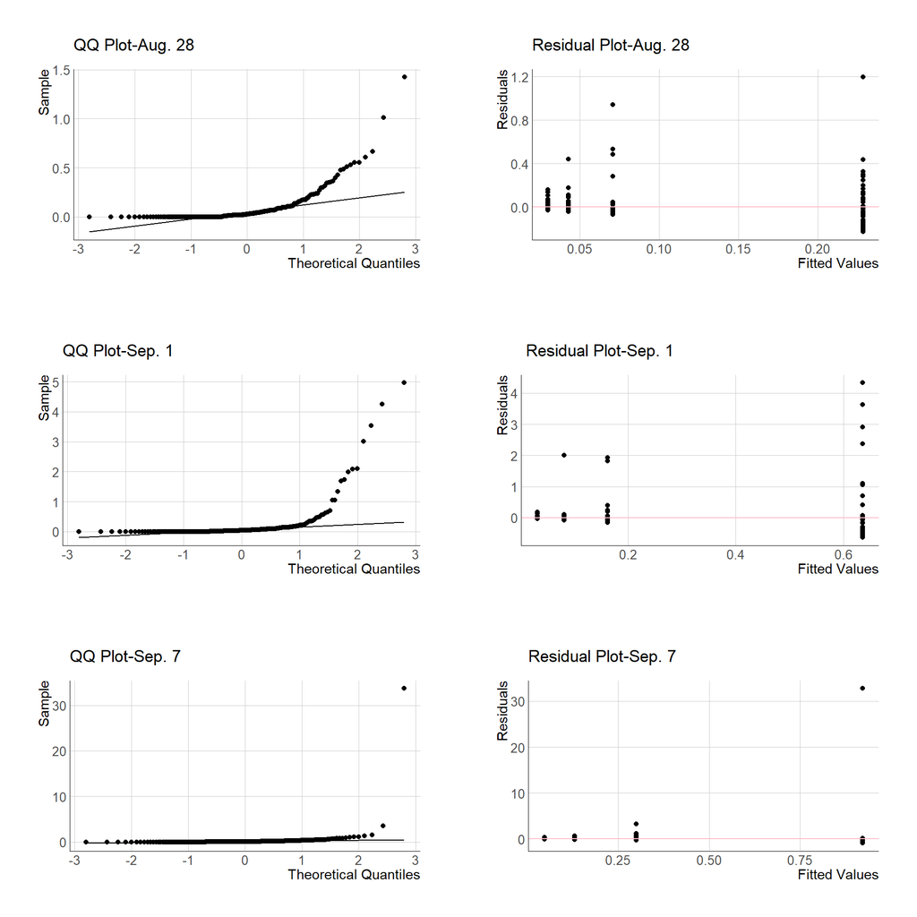

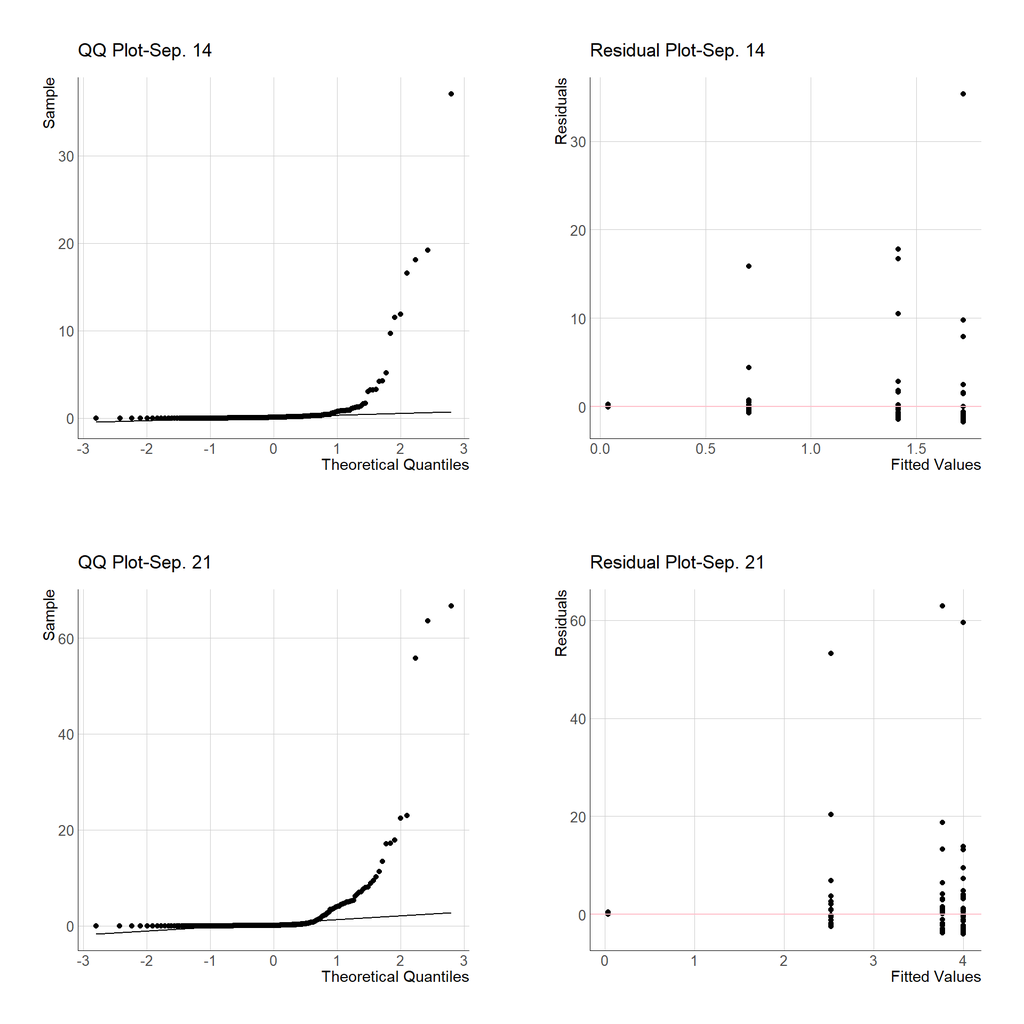

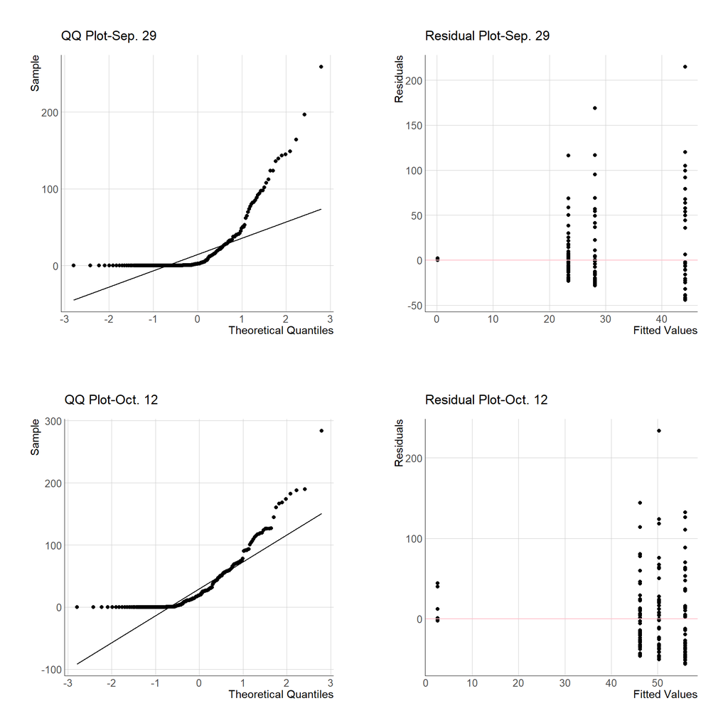

### Natural Log Transformation

Exploratory plots showed that natural log transforming IEC appeared to normalize data, diagnostic meausres for untransformed data showed that data was very messy, further analysis was done

```r
iec %>%
  mutate(iec.Aug.28.log = log(iec.Aug.28),
         iec.Sep.1.log = log(iec.Sep.1),
         iec.Sep.7.log = log(iec.Sep.7),
         iec.Sep.14.log = log(iec.Sep.14),
         iec.Sep.21.log = log(iec.Sep.21),
         iec.Sep.29.log = log(iec.Sep.29),
         iec.Oct.12.log = log(iec.Oct.12)) %>%
  select(row, treatment, rep, fruit, iec.Aug.28.log, iec.Sep.1.log , iec.Sep.7.log, iec.Sep.14.log,
         iec.Sep.21.log, iec.Sep.29.log, iec.Oct.12.log) %>%
  rename(iec.Aug.28 = iec.Aug.28.log,
         iec.Sep.1 = iec.Sep.1.log,
         iec.Sep.7 = iec.Sep.7.log,
         iec.Sep.14 = iec.Sep.14.log,
         iec.Sep.21 = iec.Sep.21.log,
         iec.Sep.29 = iec.Sep.29.log,
         iec.Oct.12 = iec.Oct.12.log) ->iec.log
iec.log <- do.call(data.frame, lapply(iec.log,
                                      function(x) replace(x, is.infinite(x), NA)))
```

The following are the p-values for diagnostic test statics on each date after natural log transformation…

#### **Aug. 28**

Neither test statistic was significant…

```
##
##  Shapiro-Wilk normality test
##
## data:  iecAug28.resid
## W = 0.98577, p-value = 0.183
```

```
## Levene's Test for Homogeneity of Variance (center = median)
##        Df F value Pr(>F)
## group   3  1.6446 0.1823
##       129
```

#### **Sep. 1**

Only the Shapiro-Wilkes test statistic was significant…

```
##
##  Shapiro-Wilk normality test
##
## data:  iecSep1.resid
## W = 0.96613, p-value = 0.001514
```

```
## Levene's Test for Homogeneity of Variance (center = median)
##        Df F value  Pr(>F)
## group   3  2.2418 0.08625 .
##       136
## ---
## Signif. codes:  0 '***' 0.001 '**' 0.01 '*' 0.05 '.' 0.1 ' ' 1
```

#### **Sep. 7**

Only the Shapiro-Wilkes test statistic was significant…

[output not shown]

```
##
##  Shapiro-Wilk normality test
##
## data:  iecSep7.resid
## W = 0.97358, p-value = 0.005665
```

```
## Levene's Test for Homogeneity of Variance (center = median)
##        Df F value  Pr(>F)
## group   3  2.2357 0.08659 .
##       145
## ---
## Signif. codes:  0 '***' 0.001 '**' 0.01 '*' 0.05 '.' 0.1 ' ' 1
```

#### **Sep. 14**

```
##
##  Shapiro-Wilk normality test
##
## data:  iecSep14.resid
## W = 0.97403, p-value = 0.004819
```

```
## Levene's Test for Homogeneity of Variance (center = median)
##        Df F value   Pr(>F)
## group   3  4.9888 0.002499 **
##       152
## ---
## Signif. codes:  0 '***' 0.001 '**' 0.01 '*' 0.05 '.' 0.1 ' ' 1
```

#### **Sep. 21**

Only Levene’s test statistic was significant…

```
##
##  Shapiro-Wilk normality test
##
## data:  iecSep21.resid
## W = 0.98519, p-value = 0.1112
```

```
## Levene's Test for Homogeneity of Variance (center = median)
##        Df F value    Pr(>F)
## group   3   6.096 0.0006184 ***
##       145
## ---
## Signif. codes:  0 '***' 0.001 '**' 0.01 '*' 0.05 '.' 0.1 ' ' 1
```

#### **Sep. 29**

Test statistic was significant for both indices…

```
##
##  Shapiro-Wilk normality test
##
## data:  iecSep29.resid
## W = 0.96303, p-value = 9.861e-05
```

```
## Levene's Test for Homogeneity of Variance (center = median)
##        Df F value    Pr(>F)
## group   3  10.065 3.689e-06 ***
##       178
## ---
## Signif. codes:  0 '***' 0.001 '**' 0.01 '*' 0.05 '.' 0.1 ' ' 1
```

#### **Oct. 12**

Only the Shapiro-Wilkes test statistic was significant…

```
##
##  Shapiro-Wilk normality test
##
## data:  iecOct12.resid
## W = 0.93746, p-value = 3.695e-07
```

```
## Levene's Test for Homogeneity of Variance (center = median)
##        Df F value Pr(>F)
## group   3   1.465 0.2257
##       180
```

Data was still mostly non parametric, but looked better than untransformed data.

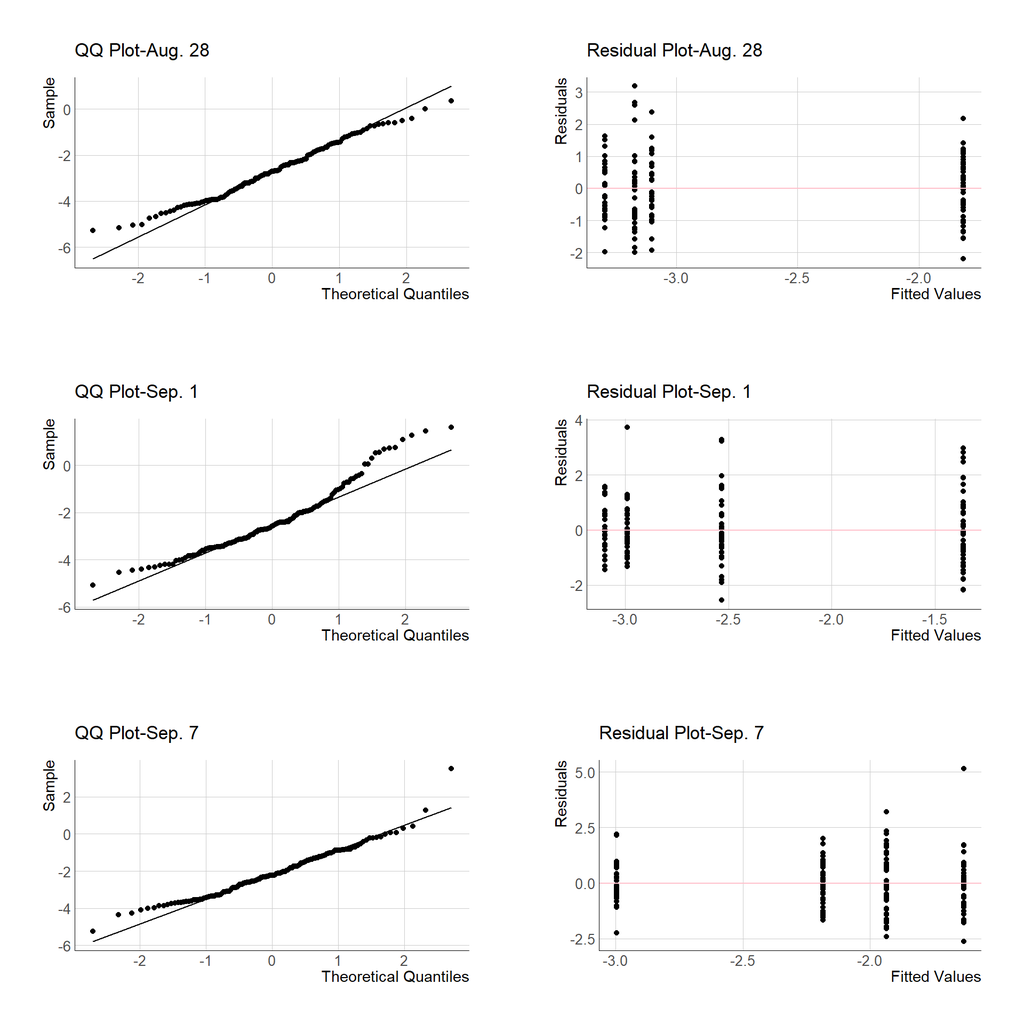

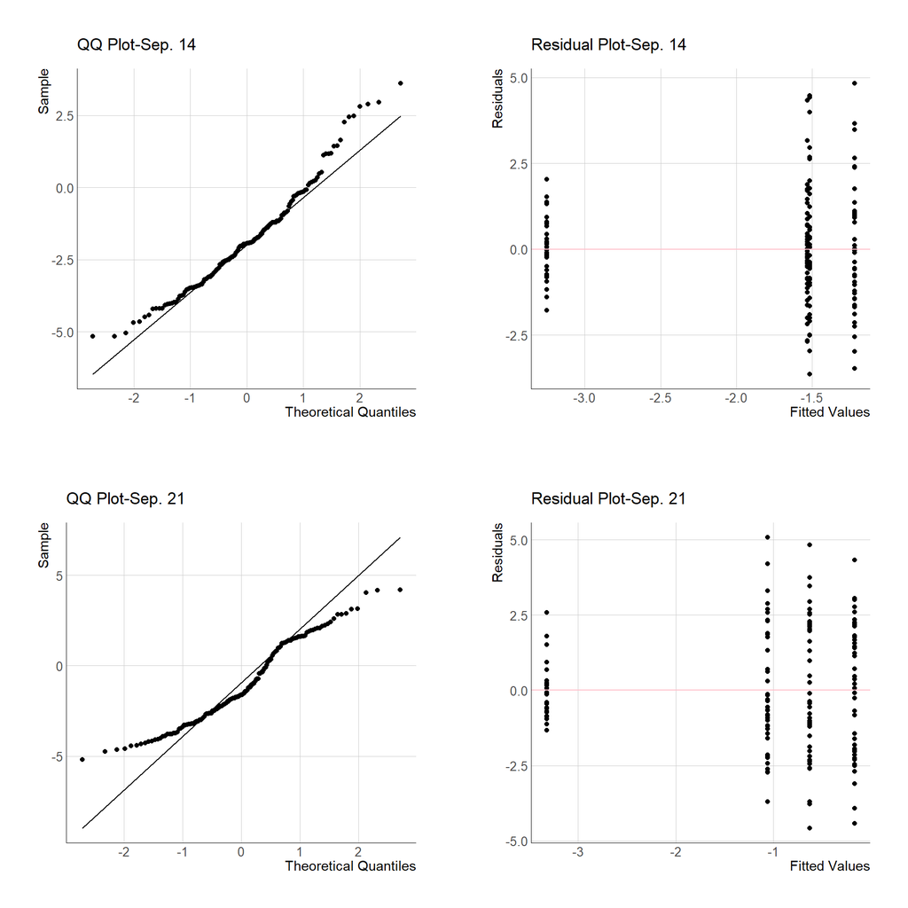

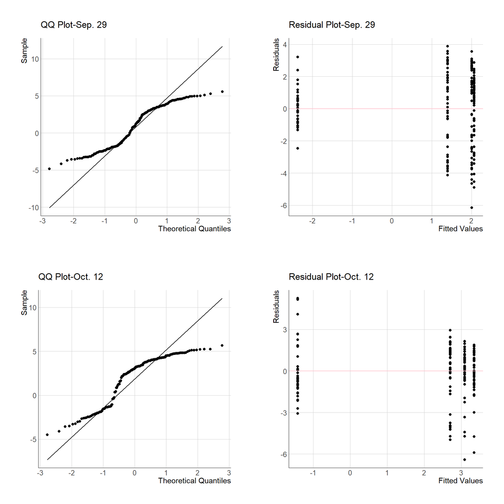

## Pairwise Comparisons of Natural Log Transformed Data

All treatment comparisons were made using log transformed data

#### **Aug. 28**

August 28 was the only date that didn’t violate ANOVA assumptions and therefore Tukey’s HSD was used…

```
##   Tukey multiple comparisons of means
##     95% family-wise confidence level
##
## Fit: aov(formula = iec.Aug.28 ~ treatment, data = iec.log)
##
## $treatment
##                      diff        lwr        upr     p adj
## ctrl-avg       0.19338475 -0.5267557  0.9135252 0.8973099
## ethephon-avg   1.47818453  0.8349284  2.1214406 0.0000001
## naa-avg        0.12332171 -0.5847147  0.8313581 0.9688704
## ethephon-ctrl  1.28479978  0.6415437  1.9280559 0.0000045
## naa-ctrl      -0.07006304 -0.7780994  0.6379734 0.9939822
## naa-ethephon  -1.35486282 -1.9845387 -0.7251870 0.0000007
```

#### **Sep. 1**

```
##
##  Kruskal-Wallis rank sum test
##
## data:  iec.Sep.1 by treatment
## Kruskal-Wallis chi-squared = 39.301, df = 3, p-value = 1.499e-08
```

```
##
##  Pairwise comparisons using Wilcoxon rank sum test
##
## data:  iec.log$iec.Sep.1 and iec.log$treatment
##
##          avg     ctrl    ethephon
## ctrl     0.10913 -       -
## ethephon 3.8e-06 0.00022 -
## naa      0.84355 0.10913 4.7e-07
##
## P value adjustment method: BH
```

#### **Sep. 7**

```
##
##  Kruskal-Wallis rank sum test
##
## data:  iec.Sep.7 by treatment
## Kruskal-Wallis chi-squared = 22.734, df = 3, p-value = 4.589e-05
```

```
##
##  Pairwise comparisons using Wilcoxon rank sum test
##
## data:  iec.log$iec.Sep.7 and iec.log$treatment
##
##          avg     ctrl   ethephon
## ctrl     0.0029  -      -
## ethephon 2.5e-05 0.0535 -
## naa      0.0029  0.4984 0.3990
##
## P value adjustment method: BH
```

#### **Sep. 14**

```
##
##  Kruskal-Wallis rank sum test
##
## data:  iec.Sep.14 by treatment
## Kruskal-Wallis chi-squared = 33.174, df = 3, p-value = 2.959e-07
```

```
##
##  Pairwise comparisons using Wilcoxon rank sum test
##
## data:  iec.log$iec.Sep.14 and iec.log$treatment
##
##          avg     ctrl ethephon
## ctrl     1.6e-06 -    -
## ethephon 6.7e-05 0.71 -
## naa      1.3e-06 0.71 0.83
##
## P value adjustment method: BH
```

#### **Sep. 21**

```
##
##  Kruskal-Wallis rank sum test
##
## data:  iec.Sep.21 by treatment
## Kruskal-Wallis chi-squared = 36.779, df = 3, p-value = 5.124e-08
```

```
##
##  Pairwise comparisons using Wilcoxon rank sum test
##
## data:  iec.log$iec.Sep.21 and iec.log$treatment
##
##          avg     ctrl ethephon
## ctrl     1.4e-08 -    -
## ethephon 2.6e-07 0.38 -
## naa      1.0e-05 0.11 0.32
##
## P value adjustment method: BH
```

#### **Sep. 29**

```
##
##  Kruskal-Wallis rank sum test
##
## data:  iec.Sep.29 by treatment
## Kruskal-Wallis chi-squared = 69.53, df = 3, p-value = 5.382e-15
```

```
##
##  Pairwise comparisons using Wilcoxon rank sum test
##
## data:  iec.log$iec.Sep.29 and iec.log$treatment
##
##          avg     ctrl ethephon
## ctrl     < 2e-16 -    -
## ethephon 6.7e-10 0.37 -
## naa      3.2e-11 0.48 0.23
##
## P value adjustment method: BH
```

#### **Oct. 12**

```
##
##  Kruskal-Wallis rank sum test
##
## data:  iec.Oct.12 by treatment
## Kruskal-Wallis chi-squared = 70.141, df = 3, p-value = 3.981e-15
```

```
##
##  Pairwise comparisons using Wilcoxon rank sum test
##
## data:  iec.log$iec.Oct.12 and iec.log$treatment
##
##          avg     ctrl ethephon
## ctrl     1.3e-11 -    -
## ethephon 3.0e-12 0.61 -
## naa      1.3e-10 0.82 0.47
##
## P value adjustment method: BH
```

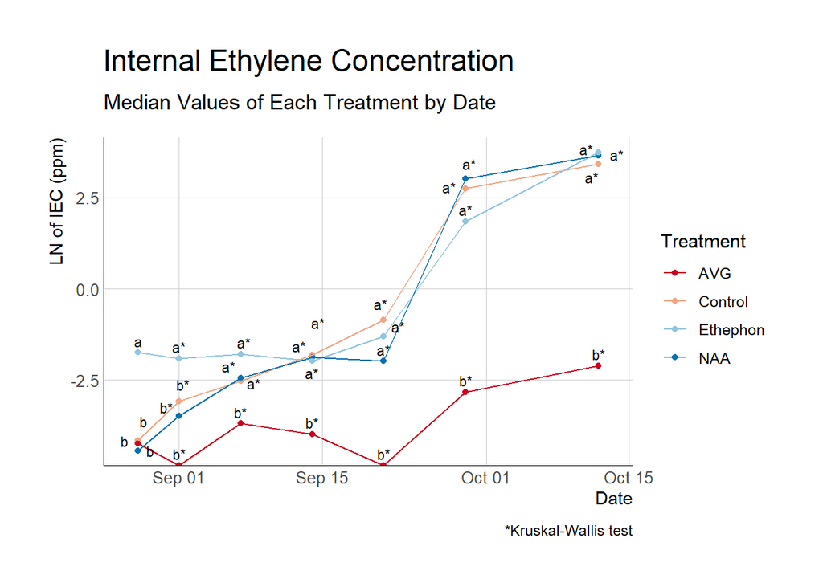